# Project2

Xiang Li, Jenny Li

2021/11/3

> Introduction to Topic

Sport, as an area receiving increased attention, responds as a result of increased awareness of people to their physical health, especially during the weird year 2020, where the pandemic changes the way of living as well as sport. Some sports benefit from it, some in alternative. Power lifting is a strength sport that consists of three attempts at maximal weight on three lifts: squat, bench press, and dead lift. At the same time, a perfect self-training exercise while staying at home during the pandemic. The central question of power lifting is how to lift successfully. This report contributes to discussing why someone successfully lifted as they expected while others didn’t use logistic regression.

> Research Questions

In order to find out why someone is more likely to lift while others don’t, we decided to use the dataset that records the information of power lifting competitions over 22,000 meets and 412,000 lifters from competitors worldwide. Based on the massive amount of data, for accuracy and feasibility, we decided to narrow down our research question to: does a lifter’s age and equipment impact the chance that they successfully lifted as expected? The response variable in this question contains a binary outcome, which would be narrowed down as the results in the category Squat1kg. The two explanatory variables are age and equipment. For the age class, we plan to focus on two specific age groups: “20-23” and “24-34”. For equipment, we focus on the most popular equipment: “Raw” and “Single-ply”. (Raw is categorized as equipment in the data, thus we continue it as equipment here.)

> Data Context

```r
# loading dataset
lifting <- read_csv (file = "openpowerlifting.csv")
```

> Cleaning

Since we are only focusing on the age class between “20-23” and “24-34” and equipment between “Raw” and “Single-ply”, we filter the dataset left cases, in this particular dataset–participants, that fit either one of the age class while matching with either one of the equipment. In addition, since it is a binary outcome, we add a new variable called “LiftingSucess” which contains values of only 1 and 0, in which 1 refers to successful lifting while 0 refers to the failure of lifting based on the result of Squat1kg. Thus, after all the filtering, there are 120809 cases left in our dataset.

```
## # A tibble: 17 x 2
##    AgeClass  Count
##    <chr>     <int>
##  1 13-15     25640
##  2 16-17     46165
##  3 18-19     64024
##  4 20-23    136701
##  5 24-34    244197
##  6 35-39     66258
##  7 40-44     63917
##  8 45-49     45746
##  9 5-12       2779
## 10 50-54     36031
## 11 55-59     21930
## 12 60-64     15384
## 13 65-69      8650
## 14 70-74      5807
## 15 75-79      2474
## 16 80-999     1097
## 17 <NA>     636554
```

```
## # A tibble: 4 x 2
##   Equipment  Count
##   <chr>      <int>
## 1 Multi-ply   6223
## 2 Raw        80660
## 3 Single-ply 40149
## 4 Wraps      26828
```

> Exploratory Data Analysis

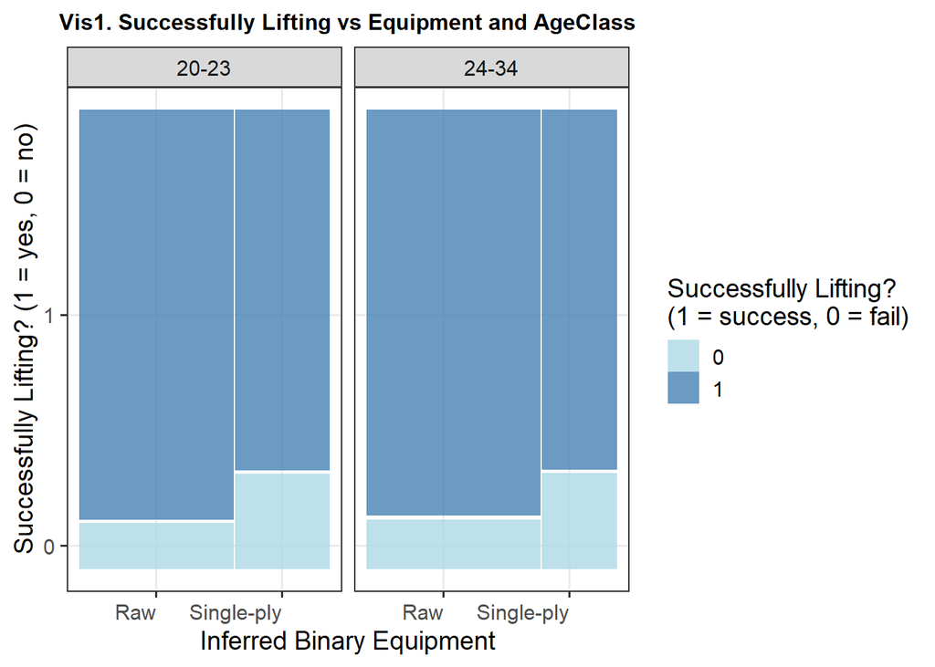

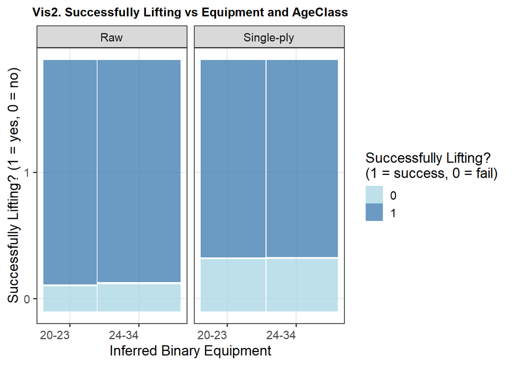

> Model Creation

> Research Question:Are lifters in age class 20-23 more likely to success than the ageclass 24-34 in Squat1kg?

$$log(\widehat{Odds}[ Lifting Success = 1 | ageclass, equipment ] = \beta_0 + \beta_1 ageclass24-34 + \beta_2 equipmentSingleply$$
We consider that equipment would be a direct predictor of whether the lifter successfully lifted. At the same time, age class might be a confounder that is worth including since people of different age classes might prefer different equipment, and it might also directly affect the results. Other variables such as age, we consider redundant toward the age class, and the success rate of different lifting attempts is similar to the Squat 1kg. A logistic regression model is used to predict the categorical dependent variable with the help of independent variables. We fit this dataset in logistic regression because Lifting Success is a binary categorical outcome, which fits better in the logistic regression model. As mentioned earlier, for accessibility, we only choose two variables that we are most interested in as the explanatory variables. Within the age class, we only choose the two that contain the most data to analyze and the equipment.

> Fitted Model

```
##
## Call:  glm(formula = LiftingSuccess ~ AgeClass + Equipment, family = binomial)
##
## Coefficients:
##         (Intercept)        AgeClass24-34  EquipmentSingle-ply
##             2.18156             -0.05063             -0.82209
##
## Degrees of Freedom: 120808 Total (i.e. Null);  120806 Residual
## Null Deviance:       97400
## Residual Deviance: 95070     AIC: 95070
```

```
## # A tibble: 3 x 8
##   term      estimate std.error statistic p.value conf.low conf.high estimate_exp
##   <chr>        <dbl>     <dbl>     <dbl>   <dbl>    <dbl>     <dbl>        <dbl>
## 1 (Interce~   2.18      0.0156    139.   0         2.15      2.21          8.86
## 2 AgeClass~  -0.0506    0.0171     -2.96 0.00304  -0.0841   -0.0172        0.951
## 3 Equipmen~  -0.822     0.0169    -48.6  0        -0.855    -0.789         0.440
```

```
##                         2.5 %    97.5 %
## (Intercept)         8.5934111 9.1367637
## AgeClass24-34       0.9193130 0.9829742
## EquipmentSingle-ply 0.4251832 0.4543181
```

|  | Estimate (exp) | Standard Error | Lower 95% CI | Upper 95% CI | P-value |
| --- | --- | --- | --- | --- | --- |
| (Intercept) | 8.8600 | 0.0156399 | 8.5934 | 9.1368 | 0.000 |
| ageclass24-34 | 0.9506 | 0.0170803 | 0.9193 | 0.9830 | 0.003 |
| equipmentSingle-ply | 0.4395 | 0.0169072 | 0.4252 | 0.4543 | 0.000 |

> Model Interpretation

> Model Evaluation

```
## # A tibble: 8 x 5
## # Groups:   Equipment, AgeClass [4]
##   Equipment  AgeClass LiftingSuccess     n condprop
##   <chr>      <chr>             <dbl> <int>    <dbl>
## 1 Raw        20-23                 0  3131   0.0995
## 2 Raw        20-23                 1 28342   0.901
## 3 Raw        24-34                 0  5281   0.107
## 4 Raw        24-34                 1 43906   0.893
## 5 Single-ply 20-23                 0  3973   0.208
## 6 Single-ply 20-23                 1 15173   0.792
## 7 Single-ply 24-34                 0  4406   0.210
## 8 Single-ply 24-34                 1 16597   0.790
```

For the numerical summary, we look at the conditional proportion of lifters who did or did not successfully lift, given the lifter’s inferred age class and equipment. It has shown a 90 percent chance that a lifter could successfully lift when falling into the category of 20-23 age class and with raw equipment, whereas when the lifter is in the age class of 24-34 and with raw equipment, the chance of successful lift will decrease to 89 percent. This is in line with the exponentiated beta 1 in the logistic model, the exponentiated coefficient of the age class variable, which is approaching 1, that although larger age might have a negative effect on the success rate of lift, it does not have a large impact on it. Moreover, if the lifter fell into the category of age class 20-23 and with Single-ply equipment, the chance of successful lift would be down to 79 percent. This also matches with the exponentiated beta 2 in the logistic regression, the exponentiated coefficient of the equipment variable, that applied single-ply as the equipment when lifting has a negative effect on the success rate, and it would have a relatively larger effect on it compared to the age class.

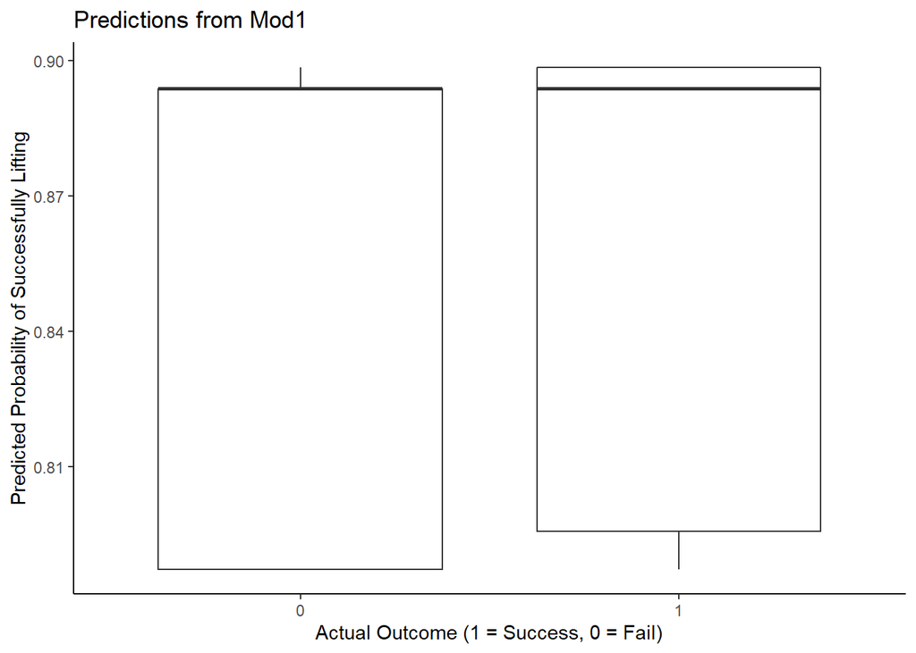

```
## Accuracy: 0.6673923
```

```
## Sensitivity: 0.6945721
```

```
## Specificity: 0.4990173
```

```
## False negative: 0.3054279
```

```
## False positive: 0.5009827
```